# IODS course project

Paula Thitz

# 1. About the project

### Feeling right now

I think I drank too much tea while doing the first set of DataCamp exercises.

### Hopes/expectations for the course

- My original motivation for taking the course stems from the fact that although I have already for a while used **RStudio as a default tool** for doing univariate statistics and figures related to them, so far I’ve felt intimidated to take it further to analyzing multivariate data. Which is a shame, as I think in the long run it would be much more efficient (timewise) to use R for all the statistics I do.
- From a less-programming/more-content point of view, the data I usually handle (plant secondary metabolites) tends to be multivariate and having a more variable set of multivariate methods in my statistical toolbox might yield important insights. Sadly, even if some of these methods have been covered in the basic statistics courses I took, it’s been a while since then, and I don’t feel confident enough to just start exploring and using the tools. So during the course I hope to develop a basic sense of
  1. **how to use the analytical tools for multivariate data**,
  2. **what kind of questions about my data I can answer with them**,  
     and
  3. **what are the worst caveats I should avoid as a beginner.**
- I never used GitHub before but can’t be too painful to learn, I hope.

### Where did I found out about the course?

I read about the course from UEF Yammer some time ago, and got interested for (or despite) the abovementioned reasons, so here we are.

[link](https://github.com/pthitz/IODS-project) to my GitHub

# 2. Regression and model validation

### 2.1 Data

```r
dat <- read.csv("D:/Opiskelu/MOOC-kurssi/IODS-project/data/lrn14_dat.csv")
str(dat)
```

```
## 'data.frame':    166 obs. of  7 variables:
##  $ gender  : Factor w/ 2 levels "F","M": 1 2 1 2 2 1 2 1 2 1 ...
##  $ age     : int  53 55 49 53 49 38 50 37 37 42 ...
##  $ attitude: num  3.7 3.1 2.5 3.5 3.7 3.8 3.5 2.9 3.8 2.1 ...
##  $ deep    : num  3.58 2.92 3.5 3.5 3.67 ...
##  $ surf    : num  2.58 3.17 2.25 2.25 2.83 ...
##  $ stra    : num  3.38 2.75 3.62 3.12 3.62 ...
##  $ points  : int  25 12 24 10 22 21 21 31 24 26 ...
```

```r
summary(dat$age)   # checking range of values on column 'age'
```

```
##    Min. 1st Qu.  Median    Mean 3rd Qu.    Max.
##   17.00   21.00   22.00   25.51   27.00   55.00
```

```r
summary(dat$points)   # checking range of values on column 'points'
```

```
##    Min. 1st Qu.  Median    Mean 3rd Qu.    Max.
##    7.00   19.00   23.00   22.72   27.75   33.00
```

Dataset is a summary of questionnaire results from 166 students who completed the exam, for which *gender* (M=male, F=female), *age* (17-55 years), and exam results (*points*) is known. The students with 0 points from the exam were removed from the data; for the students who attempted to finish the exam, exam results vary from 7-33 *points*. The questionnaire included questions measuring attitude and different learning strategies (deep, surface, or strategic learning). Corresponding summary variables *deep*, *surf* and *stra* have been transformed to equal scale by taking rowmeans (by calculating means for all questions measuring that specific learning strategy, done separately for each student.) *Attitude* has been brought to the same scale with learning strategies by dividing the initial value by 10.

*Gender* is coded as **factor** and other variables as **numeric**.

### 2.2 Graphical exploration of the data

It might be that different genders have different trends in variables. In order to visually check the possible differences, we create subsets of the data by *gender* for easy plotting.

```r
dat_males <- subset(dat,gender=="M")
dat_females <- subset(dat,gender=="F")
```

**Distributions of numerical variables**  
Boxplots will summarize data distribution nicely. However, if variables are in a very different scale, automatic scaling may cause some of the plots to show poorly. So, we first check which of the numerical variables are in the same range and thus, can be shown in the same plot.

```r
summary(dat) # check scales of variables
```

```
##  gender       age           attitude          deep            surf
##  F:110   Min.   :17.00   Min.   :1.400   Min.   :1.583   Min.   :1.583
##  M: 56   1st Qu.:21.00   1st Qu.:2.600   1st Qu.:3.333   1st Qu.:2.417
##          Median :22.00   Median :3.200   Median :3.667   Median :2.833
##          Mean   :25.51   Mean   :3.143   Mean   :3.680   Mean   :2.787
##          3rd Qu.:27.00   3rd Qu.:3.700   3rd Qu.:4.083   3rd Qu.:3.167
##          Max.   :55.00   Max.   :5.000   Max.   :4.917   Max.   :4.333
##       stra           points
##  Min.   :1.250   Min.   : 7.00
##  1st Qu.:2.625   1st Qu.:19.00
##  Median :3.188   Median :23.00
##  Mean   :3.121   Mean   :22.72
##  3rd Qu.:3.625   3rd Qu.:27.75
##  Max.   :5.000   Max.   :33.00
```

*Age* (column 2) and *points* (column 7) vary approximately on the same range. The remaining variables (columns 3-6) also share a similar range.

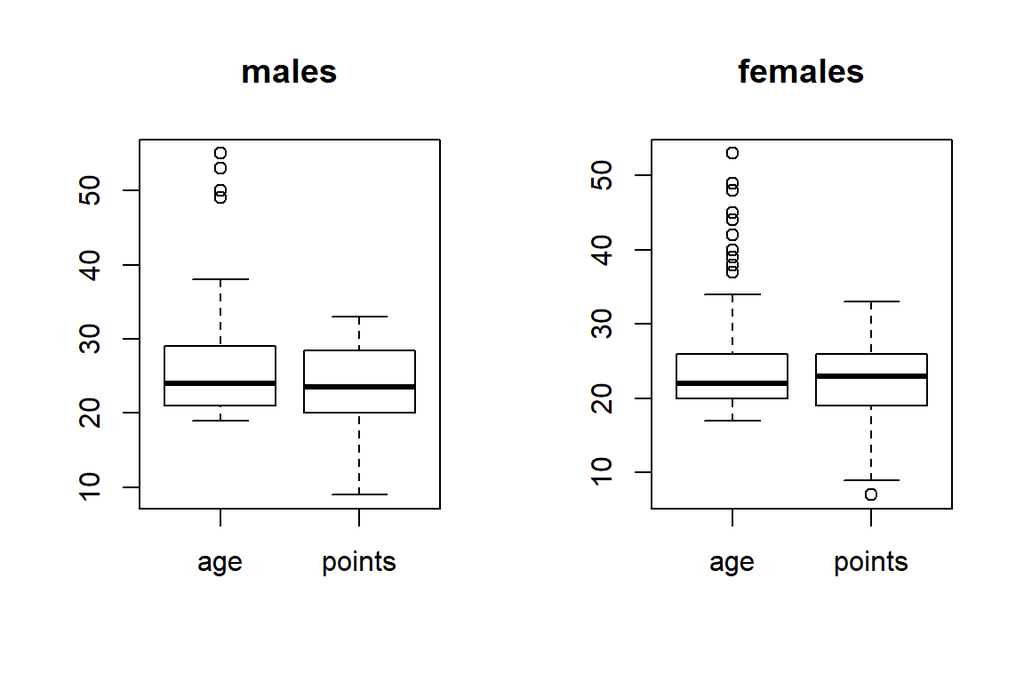

```r
par(mfrow=c(1,2)) # graphical setting tell R that I want 2 plots to appear side by side
boxplot(dat_males[,c(2,7)],main="males") # index variables [rows,columns] are used to specify that in this plot, we want to plot data in columns 2 and 7
boxplot(dat_females[,c(2,7)],main="females")
```

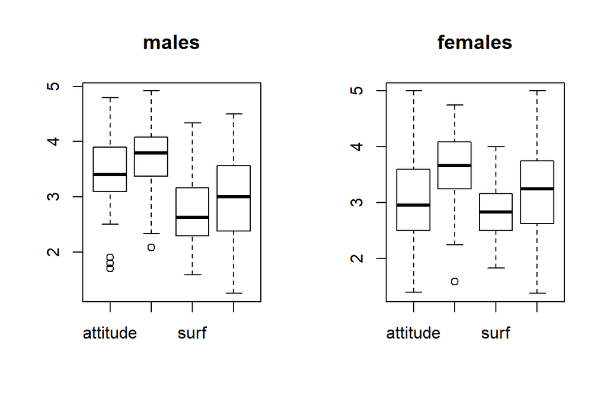

```r
boxplot(dat_males[,c(3:6)],main="males")
boxplot(dat_females[,c(3:6)],main="females")
```

Distribution of *age* is scewed (most students are between 20-30 years in both genders, but there are also several older students), but other variables seem to at least resemble a normal distribution. From the boxplots, it looks like there might be a gender difference in *attitude* (attitudes of males seem generally higher than attitudes of females), but no other gender differences are obvious from these figures.

**Relationships between numerical variables**

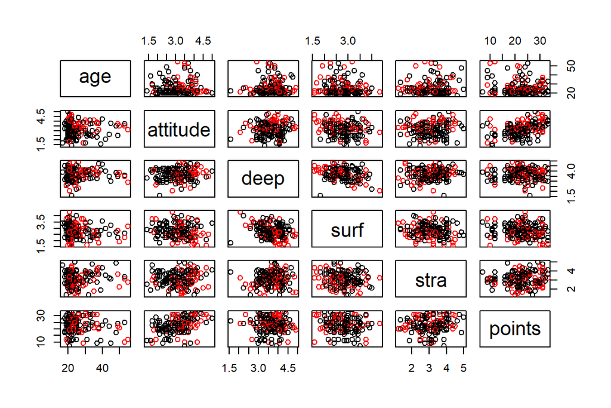

```r
pairs(dat[,-1],col=dat$gender) #scatterplot matrix of all numerical variables (excluding column 1, which is a categorical variable), points are colored according to gender
```

With so many variables the plots are a bit small and the potential trends are slightly difficult to see, but it looks like there might be a positive linear associations between variable pairs *attitude*–*deep learning* and *attitude*–*points*, and negative associations between variable pairs *age*–*surface learning*, *attitude*–*surface learning*, and *deep learning*–*surface learning*. This would mean (if not caused by pure chance) that people with positive attitude tend to achieve higher points in exam and tend to aim for deep learning instead of surface learning. Youngest students rarely had high scores in deep learning, but this did not prevent some of them from reaching very good test scores.

### 2.3 Linear regression for exam results (*points*) with three explanatory variables

In order to select variables most likely to explain exam points, let’s calculate correlations between that and other numerical variables.

```r
cor(dat[,c(2:6)],dat$points)
```

```
##                 [,1]
## age      -0.09319032
## attitude  0.43652453
## deep     -0.01014849
## surf     -0.14435642
## stra      0.14612247
```

Based on the printed table, three variables most strongly associated with points are  
1. attitude  
2. strategic learning  
3. surface learning,  
so we select these variables as initial explanatory variables.

**Initial regression model**

```r
mod1 <- lm(points~attitude+surf+stra,data=dat)
summary(mod1)
```

```
##
## Call:
## lm(formula = points ~ attitude + surf + stra, data = dat)
##
## Residuals:
##      Min       1Q   Median       3Q      Max
## -17.1550  -3.4346   0.5156   3.6401  10.8952
##
## Coefficients:
##             Estimate Std. Error t value Pr(>|t|)
## (Intercept)  11.0171     3.6837   2.991  0.00322 **
## attitude      3.3952     0.5741   5.913 1.93e-08 ***
## surf         -0.5861     0.8014  -0.731  0.46563
## stra          0.8531     0.5416   1.575  0.11716
## ---
## Signif. codes:  0 '***' 0.001 '**' 0.01 '*' 0.05 '.' 0.1 ' ' 1
##
## Residual standard error: 5.296 on 162 degrees of freedom
## Multiple R-squared:  0.2074, Adjusted R-squared:  0.1927
## F-statistic: 14.13 on 3 and 162 DF,  p-value: 3.156e-08
```

Model summary shows some summary statistics of model residuals (representing the difference between model prediction and actual values). In this case, the median is fairly close to zero and min and maximum are approximately within the same range (between 10-20). This gives us some idea about the distribution of residuals (which is centered close to zero and does not seem too skewed). We will need to check the assumptions of the final model more promptly, but so far this doesn’t look bad.

The next thing in the summary is the coefficients table. Based on the explanatory variables (*attitude*, *surf*, and *stra*), R has fitted a linear model aiming to predict points as closely as possible (to minimize residuals). Estimates essentially define this best-fitting model. Intercept tells the predicted number of *points* for an imaginary student with *attitude*, surface learning and strategic learning having a value of 0. Estimates for the other explanatory variables (which in this case were numeric) tell how much the predicted number of *points* from an exam would change if these variables increase by 1 (e.g., increasing *attitude* by 1 increases the predicted exam *points* by 3.4). Based on the non-explained variability on the data, R has also calculated us standard error for each estimate.

Each coefficient is followed by a statistical test (t and P values). These values are related to a t-test testing the null hypothesis that Estimate equals zero. P-value (Pr(>|t|) in the Coefficients-table) tells us the probability of getting an estimate like this by pure chance in a case where the variable in question does not affect exam results. So, if P-value is very low (typically, below 0.05), the data is so convincing that we will reject the null hypothesis and accept the alternative hypothesis (that the estimate really is different from zero). In this case, we interpret the t-test results so that *attitude* has a positive effect on *points*, but the effects of *surf* or *stra* are not clear enough to be considered statistically significant.

Finally, the model summary provides the degrees of freedom for the model (number of observations - number of estimates) and gives us R-squared -values, which is a measure of model fit. In this case, R<sup>2</sup>=0.20 tells us that 20% of the variability in the data can be explained by the selected explanatory variables. Adjusted R-squared adds a penalty for including too many variables which do not contribute to the model fit (overfitting the model). F-test at the end of the model summary is related to null hypothesis that all model estimates (including intercept) are zero.

**Final regression model**  
Now, our initial model included two variables (*surf* and *stra*) which did not affect exam *points*, so these variables can be left out from the final model.

```r
mod <- lm(points~attitude,data=dat)
```

### 2.4 Linear regression for exam results (*points*)

```r
summary(mod)
```

```
##
## Call:
## lm(formula = points ~ attitude, data = dat)
##
## Residuals:
##      Min       1Q   Median       3Q      Max
## -16.9763  -3.2119   0.4339   4.1534  10.6645
##
## Coefficients:
##             Estimate Std. Error t value Pr(>|t|)
## (Intercept)  11.6372     1.8303   6.358 1.95e-09 ***
## attitude      3.5255     0.5674   6.214 4.12e-09 ***
## ---
## Signif. codes:  0 '***' 0.001 '**' 0.01 '*' 0.05 '.' 0.1 ' ' 1
##
## Residual standard error: 5.32 on 164 degrees of freedom
## Multiple R-squared:  0.1906, Adjusted R-squared:  0.1856
## F-statistic: 38.61 on 1 and 164 DF,  p-value: 4.119e-09
```

The multiple R<sup>2</sup> tells us that the variability in *attitude* explains 19% of the variability in exam *points* of students.

**conclusion 1:** Attitude has a positive effect on exam scores.

### 2.5 Model assumptions

Before we rush to write a ground-breaking manuscript about our **conclusion 1**, we want to check that the general assumptions for fitting linear models were met. Most of these assumptions can be graphically explored by drawing plots about the model residuals (difference between predicted and observed values).

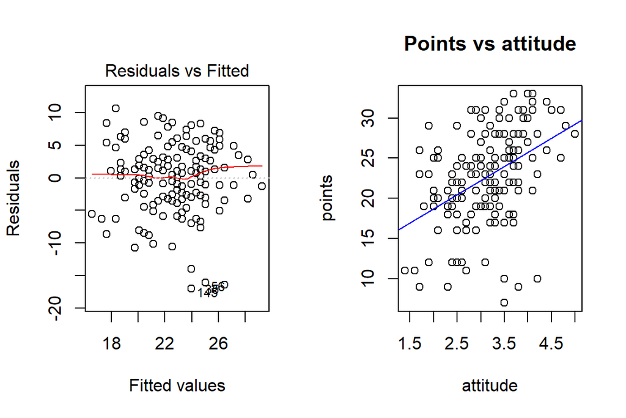

```r
par(mfrow=(c(1,2)))
plot(mod,which=1) #a diagnostic plot 'Residuals vs Fitted'
plot(dat$attitude,dat$points, xlab="attitude", ylab="points", main="Points vs attitude") #predicted vs. explanatory variable
abline(mod,col="blue") #adding a regression line (in blue) of the model to the figure. Residuals are the vertical distance of each point from this line.
```

First, we plot residuals against fitted values and the target variable (*points*) against the explanatory variable (*attitude*). These plots tell us whether the assumed linear relationship between *points* and *attitude* was correct. This seems to be the case - there is no obvious pattern on the **Residuals vs Fitted**, which tells us that the model describes the data fairly well. Another point to note is that the variability of **residuals** does not change too much when the **fitted value** changes - this tells us that the data is fairly homoscedastic. The red line in the residual figure is the mean of residuals and it remains fairly close to zero, which is also a good thing, because model assumptions expect the residuals to be centered around 0.

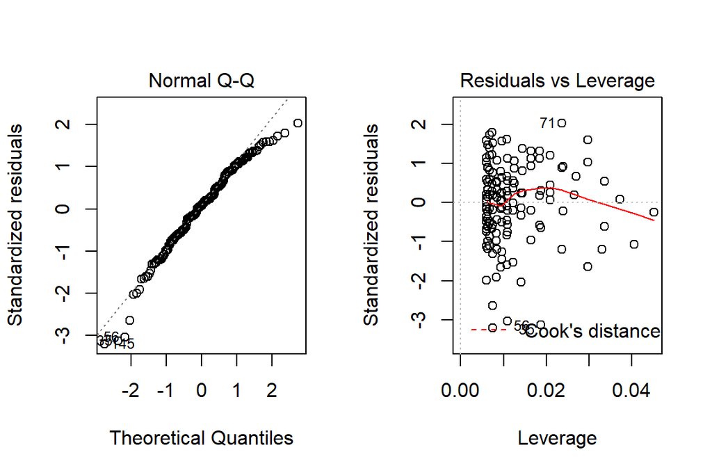

```r
par(mfrow=(c(1,2)))
plot(mod,which=c(2,5)) #diagnostic plots 'Normal Q-Q' and 'Residuals vs Leverage'
```

QQ-plot (**Normal Q-Q**) examines the distribution of residuals by comparing their distribution actual distribution (standardized residuals) into a normal distribution (theoretical quantiles). If the residuals follow the dashed line fairly well (as they do in this case), we can interpret that the residuals follow a normal distribution.  
**Residuals vs Leverage** explores whether there are data points with unusually high impact on the model. Most of the points in this plot are fairly close to each other and the scale on x-axis does not indicate too high leverage for any of the points, indicating that there are no outliers which would have an anomalously strong impact on the model.

**conclusion 2:** Model assumptions are met fairly well, which means that we can trust the result summarized in **conclusion 1**.

# 3. Logistic regression

### 3.1-3.2 Dataset: alcohol use in secondary school students

```r
alc <- read.csv("http://s3.amazonaws.com/assets.datacamp.com/production/course_2218/datasets/alc.txt" ,sep=",",header = TRUE)
names(alc)
```

```
##  [1] "school"     "sex"        "age"        "address"    "famsize"
##  [6] "Pstatus"    "Medu"       "Fedu"       "Mjob"       "Fjob"
## [11] "reason"     "nursery"    "internet"   "guardian"   "traveltime"
## [16] "studytime"  "failures"   "schoolsup"  "famsup"     "paid"
## [21] "activities" "higher"     "romantic"   "famrel"     "freetime"
## [26] "goout"      "Dalc"       "Walc"       "health"     "absences"
## [31] "G1"         "G2"         "G3"         "alc_use"    "high_use"
```

The data is a combination of questionnaire and school-collected data of 382 students, collected from two secondary schools in Portugal (see [Cortez & Silva, 2008](http://www3.dsi.uminho.pt/pcortez/student.pdf)). Dataset includes some basic background information on students (e.g. gender and age), their family relations, school history, and grades (G1-G3, averages of maths and portugues grades for 1st, 2nd and 3rd period). Students have also been asked about time and motivation they spend on studies, and some questions about their free time use[^1].

Average of alcohol consumption (*alc_use*) has been calculated from average of scores (1=very low, 5=very high) with which student described their alcohol use during week or in the week ends. Students with an average alcohol use score above 2 are considered to have a high alcohol use.

### 3.3 Aim of study and hypotheses

From a dataset described above, several interesting questions related to risk factors or consequences of high alcohol use (such as absences, failing a class, poor grades, parental support or general family situation) could be investigated. However, my interest lies more in risk-reducing aspects related to social support and aspirations of the secondary school students. In other words, I want to identify factors which reduce the chances that a student develops a high alcohol use.

Specifically, my aim is to study whether family relations (high values in `famrel`), tendency to go out with friends (high values in `goout`), being in a romantic relationship (binary variable `romantic`) or wish to take a higher education (binary variable `higher`) are related to high alcohol use among Portuguese secondary school students.

The predicted relationships between these variables are:

- *H1. Good family relations reduce the chances of developing a high alcohol use.* In secondary school students, high alcohol use might be related to the rebelling against authorities. On the other hand, in students who will occasionally use alcohol, I would assume that a good relationship with parents enables parental intervention before the alcohol use in their kids increases.
- *H2. Tendency to go out with your friends* will probably increase the occurrences of alcohol use, and thus *increase the probability for high alcohol use.* The underlying assumption is that among secondary school students, it is most common to use alcohol with your friends.
- *H3. Being in a romantic relationship reduces the probability of high alcohol use.* In some students, the reason for going out to party (which would, in most cases, include alcohol) might be a wish to find someone. Being in a relationship might decrease the need to go searching or otherwise alter the way the students use their free time in directions which involve less alcohol.
- *H4. Wish to take higher studies reduces probability for high alcohol use*, since the students with high ambition or career dreams might be more likely to spend more time on their studies, thus decreasing the time spent on parties.

### 3.4 Data exploration: family relations/study ambitions maybe linked to low alcohol consumption, and going out maybe linked to high alcohol consumption

**Distributions of chosen variables**  
For graphical exploration using functions `gather()` and `glimpse()`, let’s look at the subset of the original dataset. For data exploration purposes, we will include also the variable `alc_use` which was used for defining the target variables `high_use`.

```r
variables <- c("famrel","goout","romantic","higher","alc_use","high_use")
alc_subset <- subset(alc,select = variables)

gather(alc_subset) %>% glimpse()#gather() reorders the subsetted dataset (6 x 382 variables) into two columns "key" (variable names) and "value", so that the gathered dataset is a matrix of 2292 (=6x382) rows and 2 columns
```

```
## Observations: 2,292
## Variables: 2
## $ key   <chr> "famrel", "famrel", "famrel", "famrel", "famrel", "famre...
## $ value <chr> "4", "5", "4", "3", "4", "5", "4", "4", "4", "5", "3", "...
```

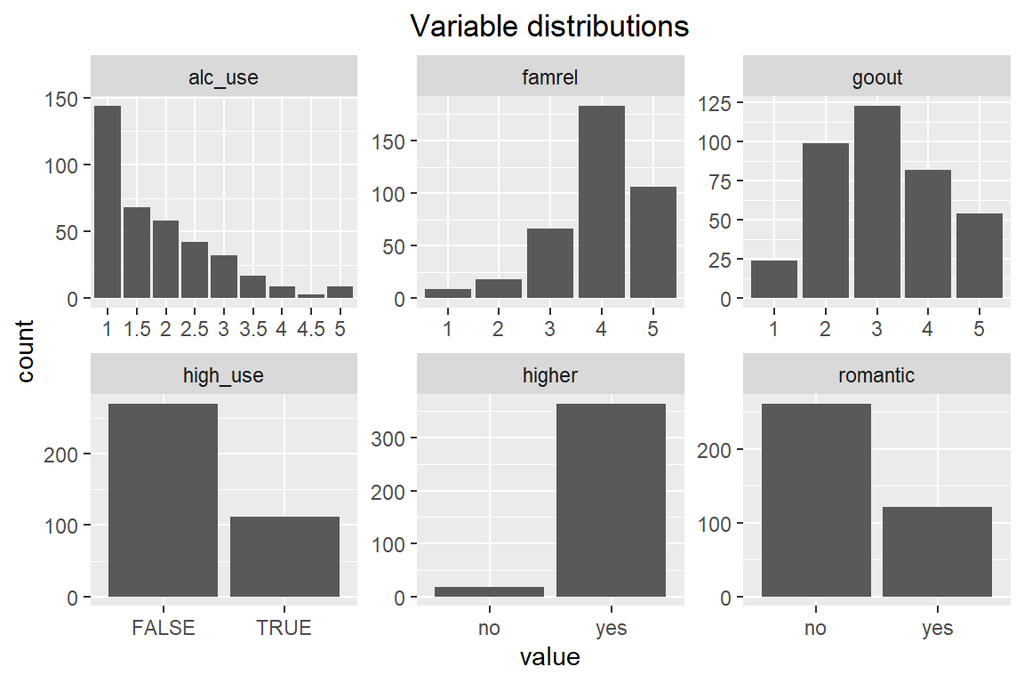

```r
gather(alc_subset) %>% ggplot(aes(value)) + facet_wrap("key", scales = "free") + geom_bar() + ggtitle("Variable distributions") + theme(plot.title = element_text(hjust=0.5))
```

From the bar plots of numerical variables (on the first row), we can see that `goout` seems normally distributed but distributions of alcohol use (`alc_use`) and family relationships `famrel` are skewed. Most of the secondary school students use very little alcohol and have fairly good relationship with their families.

From the binary variables (on the second row), we can see that most of the students do not have a high alcohol use and are not in a romantic relationship, but grand majority of them do hope to pursue higher education. This is maybe good news for the students but may indicate poor predictive power for the variable `higher`, unless every student not wishing to aim for higher education uses a lot of alcohol, see *hypothesis 4*.

**Relationships between the target and predictor variables**  
To start exploring how predictor variables might be related to the alcohol use or high alcohol use, let’s tabulate the number of students in each group and mean alcohol use per each group of categorical predictor variables.

```r
alc_subset %>% group_by(romantic,higher) %>% summarise(count = n(), mean_famrel=mean(famrel), mean_goout=mean(goout), mean_alcuse = mean(alc_use))
```

```
## # A tibble: 4 x 6
## # Groups:   romantic [2]
##   romantic higher count mean_famrel mean_goout mean_alcuse
##   <fct>    <fct>  <int>       <dbl>      <dbl>       <dbl>
## 1 no       no         7        3.86       3.29        2.36
## 2 no       yes      254        3.99       3.10        1.84
## 3 yes      no        11        3.73       3.36        2.27
## 4 yes      yes      110        3.85       3.1         1.90
```

From this table, it looks like an aspiration for higher education decreases alcohol use: mean alcohol use for the 18 students not hoping to continue their studies is nearly 0.5 units higher than in 364 students who said they would like to continue to higher education. Since the alcohol use in these groups fall on opposing sides of the limit for high use (2), *this finding supports hypothesis 4*. It might be noteworthy that the lower alcohol use in students who wish to go for higher education may be related to more intense studying (or less friends eager to go out), since also the mean of `goout` is lower in this group.

Unlike the aspiration for higher education, being in a romantic relationship does not seem to affect alcohol use, so the means look like *hypothesis 3 is not supported by the data*. People in romantic relationship seem to have slightly lower family relationships (maybe parents have opinions on other things besides alcohol use in Portugal), but the difference in scores is really small.

Using means to summarize data with skewed distributions can be problematic, so let’s check the variability in alcohol use within in each group by looking at the following boxplot. Relationship status (`romantic`) is shown with different colors and the limit between low/high alcohol use is shown by a dashed horisontal line.

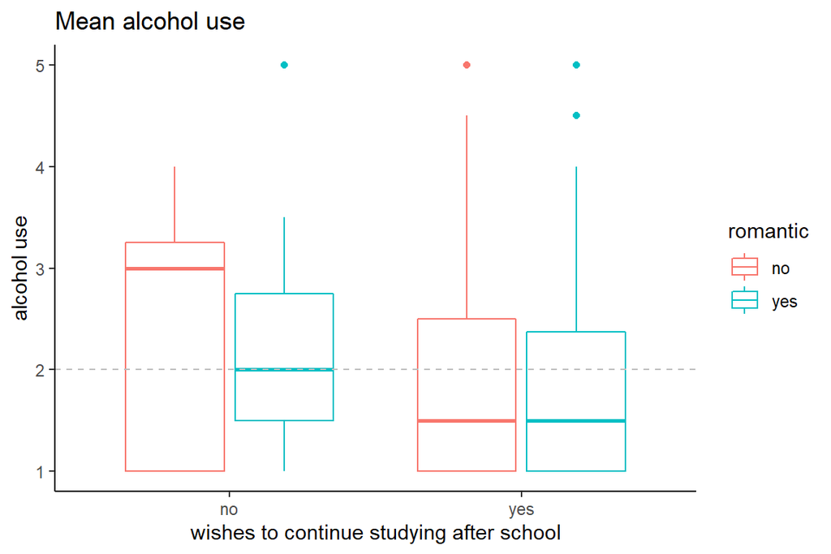

```r
g1 <- ggplot(alc_subset,aes(x=higher,y=alc_use,col=romantic))
g1 + geom_boxplot() + ylab("alcohol use") + xlab("wishes to continue studying after school") + ggtitle("Mean alcohol use") + theme_classic() + geom_hline(yintercept = 2,linetype="dashed",color="gray")
```

It looks like *we can continue believing in hypothesis 4*.

From this boxplot, it looks like it might be possible to find an interactive effect of romantic relationship and aspiration of higher studies on alcohol use - at least, if there is a reason to suspect the high alcohol use of a who is in a relationship but does not want to continue studying after secondary school. If this student can be rejected as an outlier, it seems possible that there could be an effect of relatioship within students without aspirations for higher education. However, if we don’t have a good reason to suspect exceptional circumstances or change the hypothesis to exclude this outlier, it *still does not seem that the hypothesis 3 would be supported by data*.

Exploring the potential effect of numerical variables might be easier if we tabulate the means scores for students with or without high alcohol use.

```r
alc_subset %>% group_by(high_use) %>% summarise(count = n(), mean_famrel=mean(famrel), mean_goout=mean(goout))
```

```
## # A tibble: 2 x 4
##   high_use count mean_famrel mean_goout
##   <lgl>    <int>       <dbl>      <dbl>
## 1 FALSE      270        4.01       2.86
## 2 TRUE       112        3.76       3.73
```

From this table, it looks like high alcohol use is related to lower score in family relationships and higher going-out rate (supporting *hypotheses 1* and *2*). Let’s try checking also this graphically:

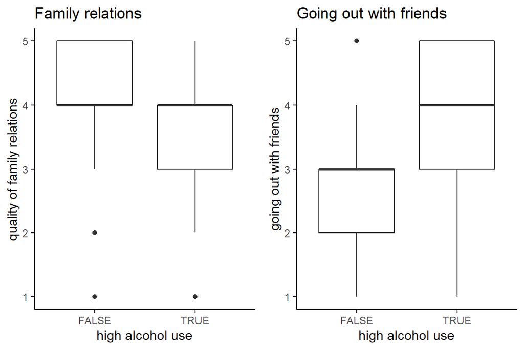

```r
g2 <- ggplot(alc_subset,aes(x=high_use,y=famrel)) + geom_boxplot() + ylab("quality of family relations") + xlab("high alcohol use") + ggtitle("Family relations") + theme_classic()
g3 <- ggplot(alc_subset,aes(x=high_use,y=goout)) + geom_boxplot() + ylab("going out with friends") + xlab("high alcohol use") + ggtitle("Going out with friends") + theme_classic()
grid.arrange(g2,g3,ncol=2)
```

The boxes (depicting the majority of observations) do not overlap in either figure, so the distribution of variables `famrel` and `goout` in students with low/high alcohol use continue to support *hypotheses 1 and 2* as described above.

### 3.5 Logistic regression model: good family relations decrease and going out with friends increases the probability for high alcohol use

Let us fit a logistic regression model `m1` to study the statistical probability that high alcohol use is related to family relations, going out with friends, being in a romantic relationship or aspirations for higher education. After fitting the model, we will print out the summary of it.

```r
m1 <- glm(high_use ~ famrel + goout + romantic + higher, data=alc, family="binomial")
summary(m1)
```

```
##
## Call:
## glm(formula = high_use ~ famrel + goout + romantic + higher,
##     family = "binomial", data = alc)
##
## Deviance Residuals:
##     Min       1Q   Median       3Q      Max
## -1.6697  -0.7554  -0.5397   0.9551   2.4742
##
## Coefficients:
##             Estimate Std. Error z value Pr(>|z|)
## (Intercept)  -0.8306     0.8243  -1.008   0.3136
## famrel       -0.4306     0.1339  -3.216   0.0013 **
## goout         0.7952     0.1189   6.690 2.23e-11 ***
## romanticyes  -0.3143     0.2735  -1.149   0.2505
## higheryes    -0.9408     0.5701  -1.650   0.0989 .
## ---
## Signif. codes:  0 '***' 0.001 '**' 0.01 '*' 0.05 '.' 0.1 ' ' 1
##
## (Dispersion parameter for binomial family taken to be 1)
##
##     Null deviance: 462.21  on 381  degrees of freedom
## Residual deviance: 398.81  on 377  degrees of freedom
## AIC: 408.81
##
## Number of Fisher Scoring iterations: 4
```

The model summary shows a reminder of model structure and some information on the residuals (on top) and the general deviance (goodness of fit, see e.g. [here](https://www.theanalysisfactor.com/r-glm-model-fit/), on bottom). For interpreting the results the important part is in the table of `Coefficients` between them. Now that the nonnumerical factor variables were binary, we do not need to worry about the contrasts, since there is only two classes of variables to compare in pairwise differences.

**Interpretation of summary of `m1`**

- From the estimates of coefficients for each variable, we see that variable `famrel` and answering yes in the questions about `romantic` and `higher` is negatively related to high alcohol use (estimate < 0), and the variable `goout` is positively related to high alcohol use (estimate > 0). These estimates would seem to support our hypotheses 1-4, but when we look at the P-values, it looks like *only the effects of family relations (P=0.001) and going out with friends (P<0.001) are statistically significant*. Very low P-values associated with these variables tell that if family relations or going out with friends does not truely affect the probability for high alcohol use, it would be highly unlike to get a dataset like this.
- *The P-value related to `romantic` is not statistically significant (P=0.251>0.05)*, meaning that even if students in a romantic relationship seemed to have less tendency for high alcohol use in this dataset, there is so much variability that the result is not clear. From this data, we cannot conclude that the relationship would affect the probability of high alcohol use – at least without collecting more data.
- *P-value associated with aspirations for higher education* is between 0.05 and 0.1. This range is sometimes called *marginally significant* - it is on a range when we can say that there is a pattern in the data, but the variability in data is still a bit too high to conclude that this pattern was not caused by chance.

To calculate the odd ratios (`OR`), we can take exponent of each of the estimates and the upper and lower limits of confidence intervals.

```r
OR <- exp(coef(m1))
CI <- exp(confint(m1))
cbind(OR,CI)
```

```
##                    OR      2.5 %    97.5 %
## (Intercept) 0.4357791 0.08335217 2.1406938
## famrel      0.6501495 0.49849143 0.8440722
## goout       2.2148780 1.76606242 2.8171861
## romanticyes 0.7302921 0.42266511 1.2387525
## higheryes   0.3902971 0.12597479 1.2041032
```

**Interpretation of odds ratios from `m1`**  
Odds ratio tells the ratio of conditional probabilities of successes compared to failures. In this case, success means that a student has a high alcohol use, whereas a failure means that a student doesn’t have a high alcohol use. The conditions are defined by explanatory variables we put to the model – so, for example the OR related to the variable `higheryes` (which means that the student answered “yes” to the question about higher education) tells us that if the student wishes to continue studying after secondary school, he/she has about 40% as likely to have a high alcohol use as the student who doesn’t want to continue studying (or conversely, that a student who doesn’t want to continue studying after secondary school is about 2.5 times as likely to have a high alcohol use (100%/40%=2,5). For numerical variables (`famrel` and `goout`), the odd ratio tells us how much an increase of one score unit in the variable increases the chance that the student has a high alcohol use.

If we combine the results from this table to those of the model summary, we should stick to interpreting ORs for statistically significant variables (for the non-significant `romanticyes` and `higheryes`, the confidence interval includes value 1, which means that based on this model, we cannot really say whether being in a relationship or wishing to continue studies increases or decreases probability of having a high alcohol use).

**Conclusions on our hypotheses based on the logistic regression model**  
Hypothesis 1 and 2 are supported by data and logistic regression, hypothesis 3 and 4 are not.

- *H1: Good family relations decrease the probability that secondary school students have a high alcohol use (P=0.001).* An improvement of 1 in “family relations”-score decreases the probability that the students have a high alcohol consumption to 50-84% (95% CI) compared to students with worse family relations. (Or a decrease in family relations increases the probability of high alcohol use by a factor of 1.5 (100/65=1.54)).
- *H2: Going out with friends increases the probability for high alcohol consumption in secondary school students (P<0.001)*. An increase of 1 in “going out”-score increases the probability that the students consume a lot of alcohol to about 1.8-2.8-fold compared to students who go out less.
- *H3: Being in a romantic relationship does not affect the chance of having a high alcohol use (P=0.25).*
- *H4: There is no sufficient evidence to conclude that hoping to continue to higher studies would have an effect on high alcohol use in secondary school students (P=0.099).*

### 3.6 The model correctly predicts the high alcohol use in 76% of the students

Here, we were asked to use only the statistically significant predictors (the most parsimonous model available), so we will make a new model `m1_simple` where we have dropped the non-significant predictors.

```r
m1_simple <- glm(high_use ~ famrel + goout, data=alc, family="binomial")
AIC(m1,m1_simple)
```

```
##           df      AIC
## m1         5 408.8108
## m1_simple  3 408.3245
```

From table above, we can note that the AIC-value associated `m1_simple` (408.32) is only slightly lower than the AIC-value of the original model `m1` (408.81), so dropping these variables did not necessary improve model fit by much, but let’s still continue with the simpler model.

We will calculate predicted `probabilities`, add them to the original dataset, and create a new column `prediction` for checking whether the model would have predicted the specific student to have high alcohol use. Then, we will cross-tabulate the results to see how well the predictions fitted the actual data.

```r
probabilities <- predict(m1_simple, type = "response")
alc <- mutate(alc, probability = probabilities)
alc <- mutate(alc, prediction = probability>0.5)
table(high_use = alc$high_use, prediction = alc$prediction)
```

```
##         prediction
## high_use FALSE TRUE
##    FALSE   243   27
##    TRUE     64   48
```

The model correctly predicted the high-alcohol use in 76% of secondary school students. It is possible that a model with a higher fit could be found by exploring the data further – since the error rate was higher in students using a lot of alcohol, maybe adding some variable highly correlated with alcohol use to the model could improve fit and predictive power of the model.

Based on the initial guesses on the relationships between the selected explanatory variables `famrel`, `goout`, `romantic` and `higher`, two out of 4 hypotheses were shown to be correct, one was incorrect (`romantic` did not have the guessed effect on high alcohol use, which - after the analysis - feels like the most far-streched of the hypotheses), and one (the effect of study ambitions on high alcohol use) was neither proved nor disproved. So, crudely comparing the guessed hypotheses (2/4 correct, one incorrect) to the training error of the model, I would say that the error rate of guessed and modelled connections in the data is about the same, but the model had a better ‘success rate’. (But the validity of this comparison can – and should be questioned, since I doubt the errors can actually seen to be on the same scale). Personally, I think both approaches are needed: scientists making educated guesses to base the hypotheses, which should then be assessed and quantified by using available statistical tools.

### 3.7 10-fold cross validation of own model (not done)

Compare the own 10-fold cross validated model to datacamp model

### 3.8 Compare performance of different models (not done)

How does number of predictors affect training/testing error rate?

# 4. Clustering and classification

### 4.1-4.2 Dataset: Boston data (from MASS-package)

```r
data("Boston")
str(Boston)
```

```
## 'data.frame':    506 obs. of  14 variables:
##  $ crim   : num  0.00632 0.02731 0.02729 0.03237 0.06905 ...
##  $ zn     : num  18 0 0 0 0 0 12.5 12.5 12.5 12.5 ...
##  $ indus  : num  2.31 7.07 7.07 2.18 2.18 2.18 7.87 7.87 7.87 7.87 ...
##  $ chas   : int  0 0 0 0 0 0 0 0 0 0 ...
##  $ nox    : num  0.538 0.469 0.469 0.458 0.458 0.458 0.524 0.524 0.524 0.524 ...
##  $ rm     : num  6.58 6.42 7.18 7 7.15 ...
##  $ age    : num  65.2 78.9 61.1 45.8 54.2 58.7 66.6 96.1 100 85.9 ...
##  $ dis    : num  4.09 4.97 4.97 6.06 6.06 ...
##  $ rad    : int  1 2 2 3 3 3 5 5 5 5 ...
##  $ tax    : num  296 242 242 222 222 222 311 311 311 311 ...
##  $ ptratio: num  15.3 17.8 17.8 18.7 18.7 18.7 15.2 15.2 15.2 15.2 ...
##  $ black  : num  397 397 393 395 397 ...
##  $ lstat  : num  4.98 9.14 4.03 2.94 5.33 ...
##  $ medv   : num  24 21.6 34.7 33.4 36.2 28.7 22.9 27.1 16.5 18.9 ...
```

Dataset `Boston` contains information about housing values in Suburbs of Boston. The dataset describes 506 towns (rows) around Boston by 14 variables including the most common value of houses (`medv`). Numerical variables contain estimates for e.g. crime, pollution (nitrogen oxygen concentrations, `nox`), average number of rooms per home (`rm`), school size (pupil-teacher ratio, `ptratio`). There’s also two nonnumerical variables (binary `chas` indicating location at riverside, and ordered index `rad` describing access to the radial highways)[^2].

### 4.3 Exploration of Boston-data

##### 4.3a Variable distributions

Let’s start looking at variable distributions using boxplots (in combination with the gather()-function, which allows us to stack the columns of the dataset Boston (506 x 14 matrix) into a 2 x 7084 matrix, where the first column contains names of variables in Boston (`key`) and the second contains values of the variables (`value`) in each town area around Boston. We also modify the `ggplot()` code from the last weeks exercises to show a boxplot instead of histograms.

```r
dim(gather(Boston))
```

```
## [1] 7084    2
```

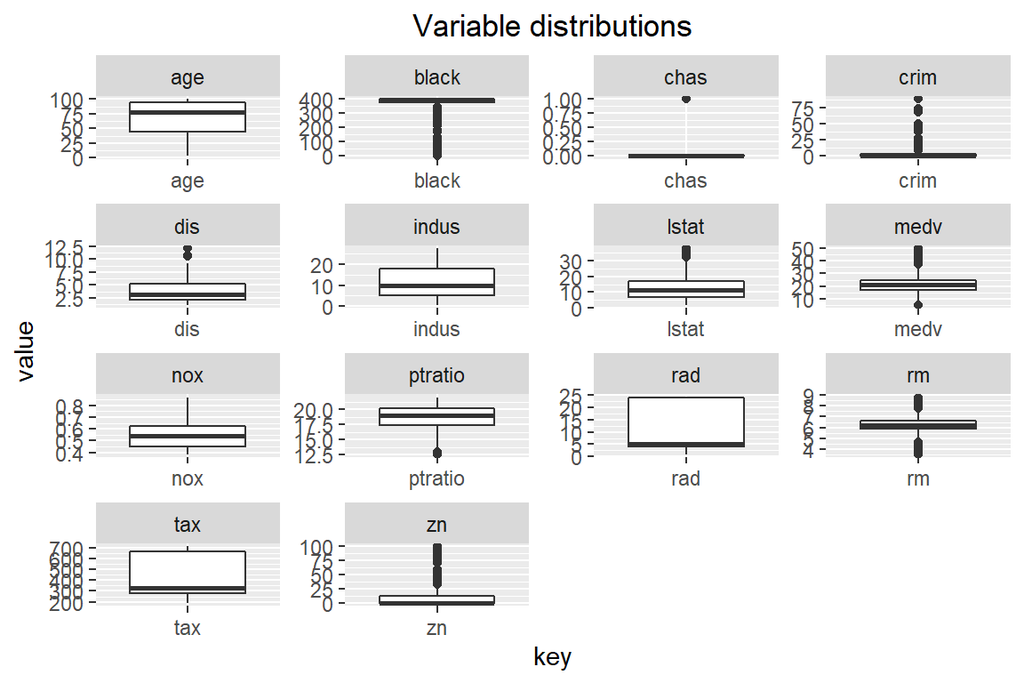

```r
gather(Boston) %>% ggplot(aes(key,value)) + facet_wrap("key", scales = "free") + geom_boxplot() + ggtitle("Variable distributions") + theme(plot.title = element_text(hjust=0.5)) #geom_boxplot() defines that the desired type is boxplot, and we need to change the first argument into aes(x,y) to define that we want to show distribution of values in each variable (key)
```

```r
summary(Boston)
```

```
##       crim                zn             indus            chas
##  Min.   : 0.00632   Min.   :  0.00   Min.   : 0.46   Min.   :0.00000
##  1st Qu.: 0.08204   1st Qu.:  0.00   1st Qu.: 5.19   1st Qu.:0.00000
##  Median : 0.25651   Median :  0.00   Median : 9.69   Median :0.00000
##  Mean   : 3.61352   Mean   : 11.36   Mean   :11.14   Mean   :0.06917
##  3rd Qu.: 3.67708   3rd Qu.: 12.50   3rd Qu.:18.10   3rd Qu.:0.00000
##  Max.   :88.97620   Max.   :100.00   Max.   :27.74   Max.   :1.00000
##       nox               rm             age              dis
##  Min.   :0.3850   Min.   :3.561   Min.   :  2.90   Min.   : 1.130
##  1st Qu.:0.4490   1st Qu.:5.886   1st Qu.: 45.02   1st Qu.: 2.100
##  Median :0.5380   Median :6.208   Median : 77.50   Median : 3.207
##  Mean   :0.5547   Mean   :6.285   Mean   : 68.57   Mean   : 3.795
##  3rd Qu.:0.6240   3rd Qu.:6.623   3rd Qu.: 94.08   3rd Qu.: 5.188
##  Max.   :0.8710   Max.   :8.780   Max.   :100.00   Max.   :12.127
##       rad              tax           ptratio          black
##  Min.   : 1.000   Min.   :187.0   Min.   :12.60   Min.   :  0.32
##  1st Qu.: 4.000   1st Qu.:279.0   1st Qu.:17.40   1st Qu.:375.38
##  Median : 5.000   Median :330.0   Median :19.05   Median :391.44
##  Mean   : 9.549   Mean   :408.2   Mean   :18.46   Mean   :356.67
##  3rd Qu.:24.000   3rd Qu.:666.0   3rd Qu.:20.20   3rd Qu.:396.23
##  Max.   :24.000   Max.   :711.0   Max.   :22.00   Max.   :396.90
##      lstat            medv
##  Min.   : 1.73   Min.   : 5.00
##  1st Qu.: 6.95   1st Qu.:17.02
##  Median :11.36   Median :21.20
##  Mean   :12.65   Mean   :22.53
##  3rd Qu.:16.95   3rd Qu.:25.00
##  Max.   :37.97   Max.   :50.00
```

From boxplots, we can see that variables are shown on very different scales, the distribution of most variables is moderately to highly skewed, and the variance also varies a lot. For example, it looks like majority of town areas are located relatively close to the radial high-way (`rad`) and have a fairly low property-tax (measured by `tax`). The `summary()` command shows us the same information visualized in boxplots.

It might be interesting to see if distributions of `tax` or `rad` (with very wide interquantile ranges) actually consist of two populations. Let’s do histograms!

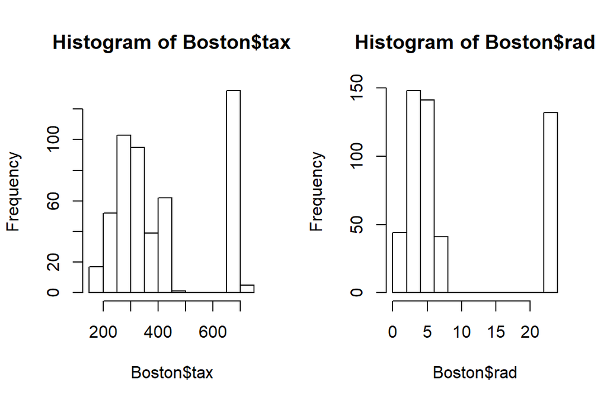

```r
par(mfrow=c(1,2))
hist(Boston$tax)
hist(Boston$rad)
```

Bingo! Besides the bulk of areas with lower tax value, there are some areas with extremely high taxes. A similar distribution is observable in the distance to highways (`rad`). To be thorough, let’s replace the initial boxplots by violin plots, which show multimodal distributions more clearly.

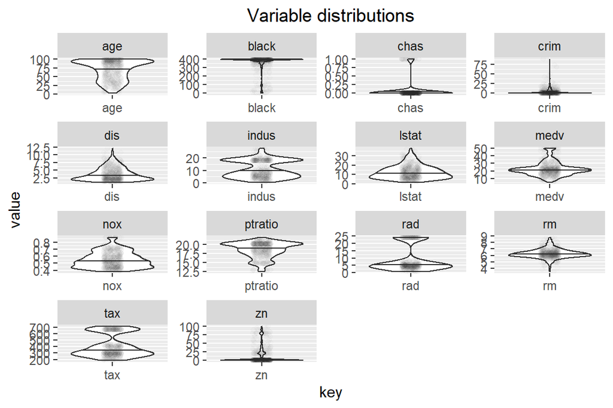

```r
gather(Boston) %>% ggplot(aes(key,value)) + facet_wrap("key", scales = "free") + geom_violin(draw_quantiles = c(0.5)) + ggtitle("Variable distributions") + theme(plot.title = element_text(hjust=0.5)) + geom_point(position = position_jitter(0.1),alpha=0.01) #changed geom_boxplot into a geom_violin (with dra_quantiles() specifying that I want to draw a median), and added geom_points to show that I want to show points on top of the distributions (position_jitter spreads the points to make them more visible, and alpha adds transparency so that the points don't steal the show from distributions)
```

##### 4.3b Relationships between variables

To see which variables could potentially be related, we will calculate correlations between all variables and save it into `cor_matrix` and use this to draw a correlation plot using `corrplot()`. In the following graps, the size and intensity of circles corresponding to correlation between variables. Blue circles mean positive correlations, red circles mean negative correlations.

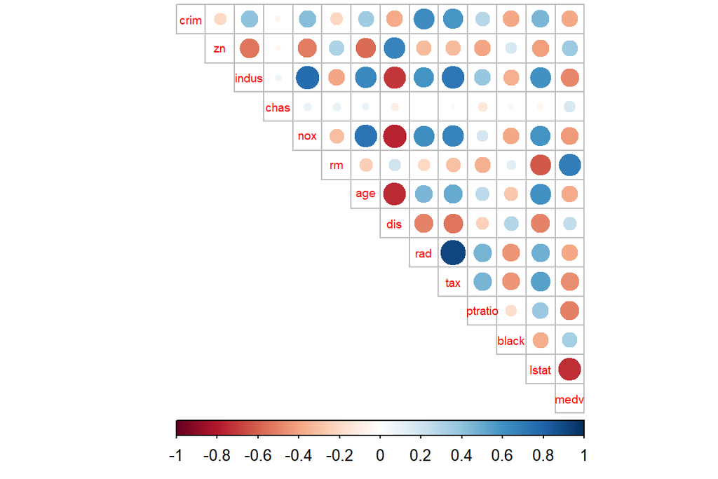

```r
cor_matrix <- cor(Boston)
corrplot(cor_matrix,method = "circle",type="upper",cl.pos = "b",tl.pos = "d",tl.cex = 0.6)
```

### 4.4 Modifications of the dataset

##### 4.4a Standardization

Different absolute values and variances might affect the multivariate methods, so to treat all variables equally, we will center each variable around its mean and scale it so that they have equal variances. This is a quick-and-dirty way to transform unimodal data closer to a normal distribution.

```r
boston_scaled <- scale(Boston)
summary(boston_scaled)
```

```
##       crim                 zn               indus
##  Min.   :-0.419367   Min.   :-0.48724   Min.   :-1.5563
##  1st Qu.:-0.410563   1st Qu.:-0.48724   1st Qu.:-0.8668
##  Median :-0.390280   Median :-0.48724   Median :-0.2109
##  Mean   : 0.000000   Mean   : 0.00000   Mean   : 0.0000
##  3rd Qu.: 0.007389   3rd Qu.: 0.04872   3rd Qu.: 1.0150
##  Max.   : 9.924110   Max.   : 3.80047   Max.   : 2.4202
##       chas              nox                rm               age
##  Min.   :-0.2723   Min.   :-1.4644   Min.   :-3.8764   Min.   :-2.3331
##  1st Qu.:-0.2723   1st Qu.:-0.9121   1st Qu.:-0.5681   1st Qu.:-0.8366
##  Median :-0.2723   Median :-0.1441   Median :-0.1084   Median : 0.3171
##  Mean   : 0.0000   Mean   : 0.0000   Mean   : 0.0000   Mean   : 0.0000
##  3rd Qu.:-0.2723   3rd Qu.: 0.5981   3rd Qu.: 0.4823   3rd Qu.: 0.9059
##  Max.   : 3.6648   Max.   : 2.7296   Max.   : 3.5515   Max.   : 1.1164
##       dis               rad               tax             ptratio
##  Min.   :-1.2658   Min.   :-0.9819   Min.   :-1.3127   Min.   :-2.7047
##  1st Qu.:-0.8049   1st Qu.:-0.6373   1st Qu.:-0.7668   1st Qu.:-0.4876
##  Median :-0.2790   Median :-0.5225   Median :-0.4642   Median : 0.2746
##  Mean   : 0.0000   Mean   : 0.0000   Mean   : 0.0000   Mean   : 0.0000
##  3rd Qu.: 0.6617   3rd Qu.: 1.6596   3rd Qu.: 1.5294   3rd Qu.: 0.8058
##  Max.   : 3.9566   Max.   : 1.6596   Max.   : 1.7964   Max.   : 1.6372
##      black             lstat              medv
##  Min.   :-3.9033   Min.   :-1.5296   Min.   :-1.9063
##  1st Qu.: 0.2049   1st Qu.:-0.7986   1st Qu.:-0.5989
##  Median : 0.3808   Median :-0.1811   Median :-0.1449
##  Mean   : 0.0000   Mean   : 0.0000   Mean   : 0.0000
##  3rd Qu.: 0.4332   3rd Qu.: 0.6024   3rd Qu.: 0.2683
##  Max.   : 0.4406   Max.   : 3.5453   Max.   : 2.9865
```

```r
boston_scaled <- as.data.frame(boston_scaled)
```

Now mean of each variable is zero and the range of variables (shown by distance from min to max, which is now in the range of -5 to 10 in all variables) are more similar than in the original `Boston` (where variable ranges could be as different as 0-1 vs. 0-400).

##### 4.4b Change numerical `crim` into a categorical `crime`

To create four `crime`-classes of equal size, we will use quantiles to define whether a town can be defined to have “low”, “medium low”, “medium high” or “high” crime, based on (standardized) per capita crime rate `crim`.

```r
bins <- quantile(boston_scaled$crim) #vector defining the cutting values for different categories of crime
crime <- cut(boston_scaled$crim, breaks = bins, include.lowest = TRUE, labels = c("low", "med_low", "med_high", "high")) #create new variables crime into boston_scaled, with selected names of categories
boston_scaled <- dplyr::select(boston_scaled, -crim) #remove original crim from data
boston_scaled <- data.frame(boston_scaled, crime) #add new crime into data
```

##### 4.4c Create training and testing datasets

We are planning to do linear discriminant analysis, which is a multivariate classification methods, later. In order to test if the classification is correct, we will split the dataset randomly into training set (containing 80% of the towns) and testing set (containing the remaining 20% of the towns).

```r
n <- nrow(boston_scaled)
ind <- sample(n,  size = n * 0.8) #choose randomly 80% of rows (these will be in the training data set)
train <- boston_scaled[ind,]
test <- boston_scaled[-ind,] #testing dataset consists of all rows not selected for the training
```

### 4.5 Linear discriminant analysis for crime rate

In order to find out which variables are typically related to each of the crime classes, we will do linear discriminant analysis (LDA) on `crime` with other 13 variables as predictors, using the training dataset we created above. Besides fitting the LDA-model, we will show the results in a biplot.

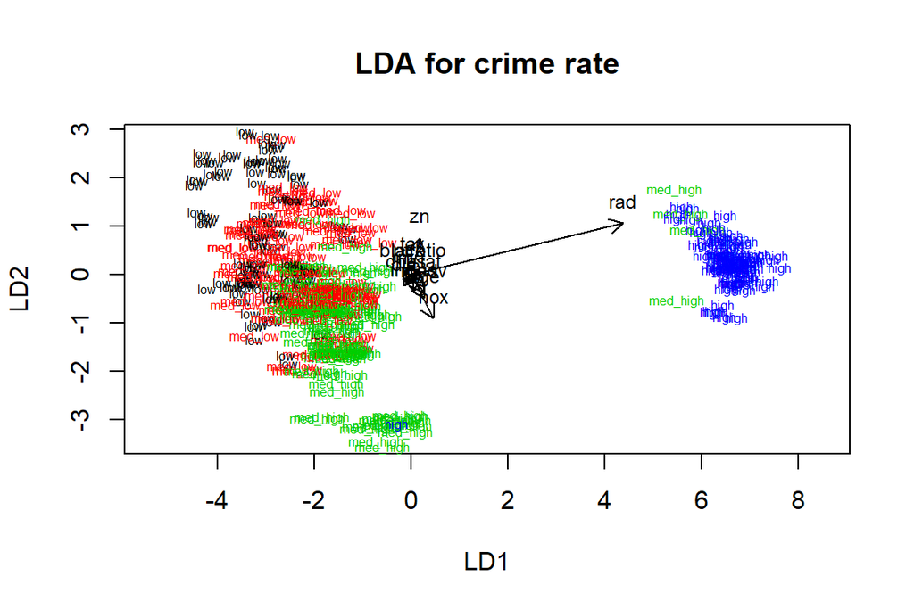

```r
lda.fit <- lda(crime~., data = train) #this creates the LDA-model

classes <- as.numeric(train$crime) #to avoid having to worry about factor levels or such, we will create a numeric copy (classes) of the categorical "crime" variable
lda.arrows <- function(x, myscale = 1, arrow_heads = 0.1, color = "black", tex = 0.75, choices = c(1,2)){
  heads <- coef(x)
  arrows(x0 = 0, y0 = 0,
         x1 = myscale * heads[,choices[1]],
         y1 = myscale * heads[,choices[2]], col=color, length = arrow_heads)
  text(myscale * heads[,choices], labels = row.names(heads),
       cex = tex, col=color, pos=3)} #function drawing arrows that will be added to the plot above to make it into a biplot

plot(lda.fit, dimen = 2,col=classes,pch=classes,cex=0.5,main="LDA for crime rate") # plotting the cases (towns) based on their distances in two dimensions. The color already separates different classes, so I reduced the symbol size (using the argument cex)
lda.arrows(lda.fit, myscale = 1.3) # add arrows (labeled with the variables they represent) making the distance plot into a biplot
```

From this plot, we see that based on all non-crime variables, town areas with high crime can be quite clearly separated from areas with less crime, although there a few “medium-high crime” areas resembling “high crime” areas (green plots in the cluster of blue) and one blue “high crime” clustering with majority of green “medium-high crime”. The long `rad` arrow tells that the variable most clearly separating “high crime” from other classes is the accessibility from the high-crime-rate-areas to the high-way.  
The other crime classes are less separated from each other based on non-crime variables, but their order from low to medium high (black-red-green) seems logical and suggests. The arrows are shorter and on top of each other, suggesting their predictive power for crime rate is lower, but it looks like high values on `zn` (related to zoning large areas for residential use) could be somewhat related to lower crime rate in the area.

### 4.6 Does the LDA fitted above predict crime correctly?

Based on the all non-crime variables in the test data set we will predict their crime classes, and cross-tabulate these predictions with the actual crime classes.

```r
correct_classes <- test$crime # save the correct classes from test data
test <- dplyr::select(test, -crime) # remove the crime variable from test data

lda.pred <- predict(lda.fit, newdata = test)
table(correct = correct_classes, predicted = lda.pred$class)
```

```
##           predicted
## correct    low med_low med_high high
##   low       17       7        0    0
##   med_low    3      17        2    0
##   med_high   1       8       16    2
##   high       0       0        0   29
```

If the prediction for crime level between town around Boston was perfect, everything but the top-left–bottom-right diagonal of this table would be zeros. Now, we can see that the `lda.fit` predicted nearly all towns with high crime correctly in the test data, but within the lower-than-high crime town areas, the predictive power of the model was lower. (The exact numbers depend on which rows were randomly selected from the original dataset, so they change every time the code is run). The difficulty of predicting the towns with lower-than-high crime was already visible in the LDA-plot based on training dataset (above): towns with low, medium-low and medium-high crime (black, red and green symbols, respectively) did not show up as distinct clusters in the plot.

### 4.7 Clustering town areas around Boston

In principle I think we could use the same dataset we loaded before (since we didn’t do any direct changes to it), but just in case: let’s reload and standardize the data.

```r
data("Boston")
boston_scaled <- scale(Boston)
boston_scaled <- as.data.frame(boston_scaled)
str(boston_scaled)
```

```
## 'data.frame':    506 obs. of  14 variables:
##  $ crim   : num  -0.419 -0.417 -0.417 -0.416 -0.412 ...
##  $ zn     : num  0.285 -0.487 -0.487 -0.487 -0.487 ...
##  $ indus  : num  -1.287 -0.593 -0.593 -1.306 -1.306 ...
##  $ chas   : num  -0.272 -0.272 -0.272 -0.272 -0.272 ...
##  $ nox    : num  -0.144 -0.74 -0.74 -0.834 -0.834 ...
##  $ rm     : num  0.413 0.194 1.281 1.015 1.227 ...
##  $ age    : num  -0.12 0.367 -0.266 -0.809 -0.511 ...
##  $ dis    : num  0.14 0.557 0.557 1.077 1.077 ...
##  $ rad    : num  -0.982 -0.867 -0.867 -0.752 -0.752 ...
##  $ tax    : num  -0.666 -0.986 -0.986 -1.105 -1.105 ...
##  $ ptratio: num  -1.458 -0.303 -0.303 0.113 0.113 ...
##  $ black  : num  0.441 0.441 0.396 0.416 0.441 ...
##  $ lstat  : num  -1.074 -0.492 -1.208 -1.36 -1.025 ...
##  $ medv   : num  0.16 -0.101 1.323 1.182 1.486 ...
```

```r
dist_eu <- dist(boston_scaled) # calculate distances and save them into a new object
km <-kmeans(boston_scaled, centers = 3) #kmeans algorithm
```

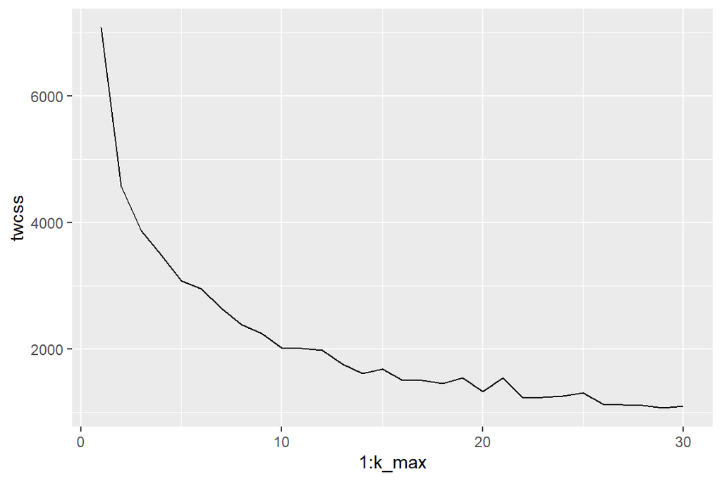

```r
set.seed(1988) #unless specified otherwise, kmeans() selects a random location for each cluster it makes when calculating twcss; this could in principle affect the plot, so we will tell it to use this number instead
k_max <- 30 #max number of clusters - if the plot doesn't seem to stabilize we could set it higher
twcss <- sapply(1:k_max, function(k){kmeans(boston_scaled, k)$tot.withinss}) #create a vector containing total WCSS-values calculated for each 1-10 solution of kmeans
qplot(x = 1:k_max, y = twcss, geom = 'line') #plot total WCSS against number of clusters
```

This case does not seem as clear as the DataCamp example, since the curve doesn’t become “bumpy” or really start to level before k=5, but the most abrupt drop of the curve ends somewhere between 2 and 3, so we will select to do clustering with k=3. (A number as high as 5 could maybe be argumented for, but to keep interpretation simpler, we will take the more parsimonous solution.)  
We will run the `kmeans()` again with this number of clusters and plot the solution to see how our data was grouped.

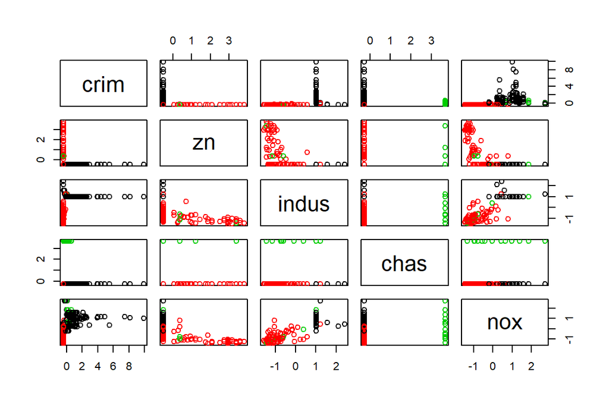

```r
km_3 <-kmeans(boston_scaled, centers = 3)
pairs(boston_scaled[1:5],col=km_3$cluster)
```

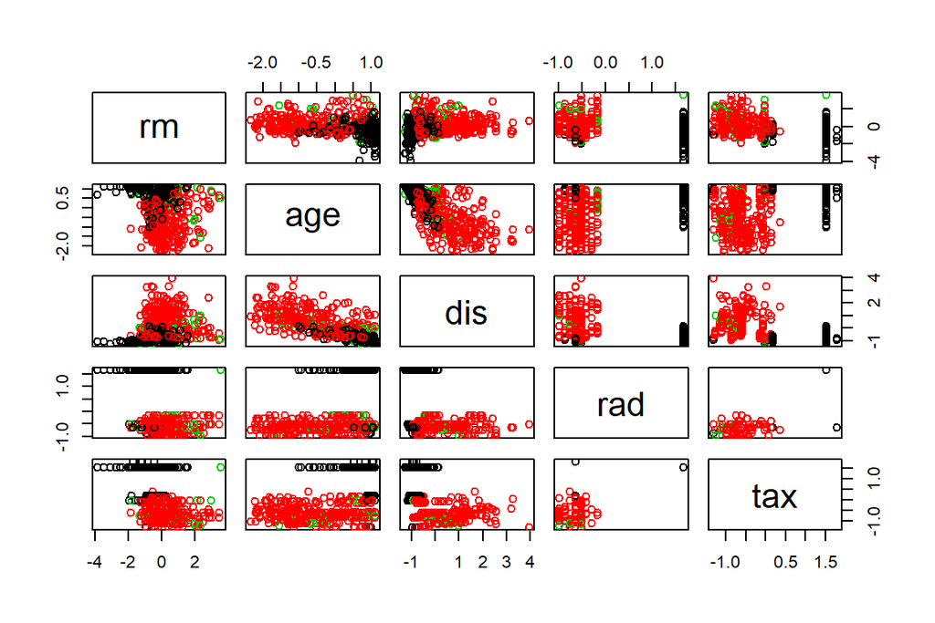

```r
pairs(boston_scaled[6:10],col=km_3$cluster)
```

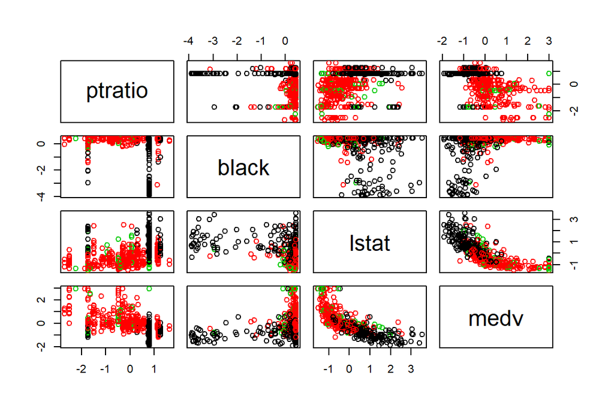

```r
pairs(boston_scaled[11:14],col=km_3$cluster)
```

- Dividing the data into 3 clusters shows that high crime rate is mostly found in the cluster marked with black. Other variables typical to this cluster seem to be high values in `tax` and `rad`, for example. (So, high crime rate in town might be correlated with high-value properties maybe describing wealthiness, and either high or low accessibility to the highways, depending on what accessibility index 1 meant.
- Red cluster seems to be related to low `tax`, high `dist`, low `nox` or `ind` and high `medv`. This could support the interpretation that these are residential areas, from where people commute to industrial/commercial centers.
- Green cluster consists of houses by the river (`chas=1`), but it is tricky to see other similarities in these towns, except potentially the low high pupil to teacher ratio (`ptratio`)

A potentially noteworthy thing is that the red and black clusters seem to be separate fairly well when the value of houses (measured by `medv`) is plotted against `lstat`, which is explained as “lower status of the population”. Without knowing how this variable is defined (or going to the potential problems of defining some people to have lower status than the others), it would look like the clustering we did relates to the higher/lower valued areas around Boston, and the visual inspection of data looks like the population with `higher/lower status` is unevenly distributed in these areas. This could represent a case of regional (economical, societal) segregation. Alternative explanation is related to zonation of different towns to either commercial/industrial (black) or residential (red) areas.

[^1]: For a full list of data attributes and their abbreviations, see https://archive.ics.uci.edu/ml/datasets/Student+Performance
[^2]: For a full list of data attributes, see https://stat.ethz.ch/R-manual/R-devel/library/MASS/html/Boston.html